# Codecademy Portfolio Project: "OKCupid Date-A-Scientist"

Project Author: Alexander Lacson

# Project Description

In this project, I will work with data from OKCupid, an online dating app. This dataset was provided to me by Codecademy as part of their "Data Science Career Path". In this project I seek to accomplish the following:

- Visualize and explore OKCupid user data.  
  *"Who uses OKCupid? What do people usually share on their profiles? How do people describe themselves?"*
- Use Machine Learning to predict gender.  
  *"If a user's gender was kept hidden, can the other pieces of information be used to correctly predict the gender? If yes, what information was most important for making the prediction?"*
- Use Unsupervised Machine Learning to create a simple dating recommendation algorithm.  
  *"Can we recommend who you should date?"*

### Disclaimer: This data is from mid 2011 to 2012

# Visualization

*Who uses OKCupid?*

## Numerical Features

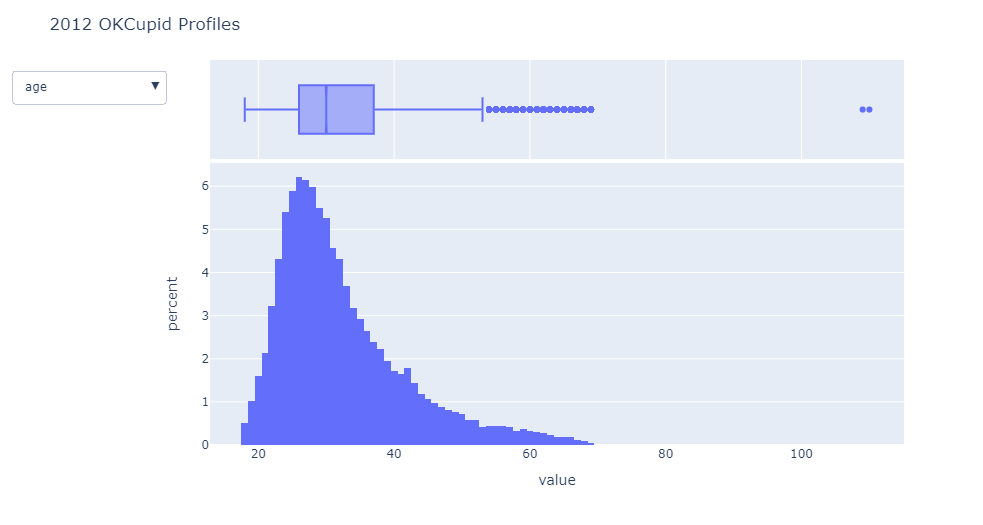

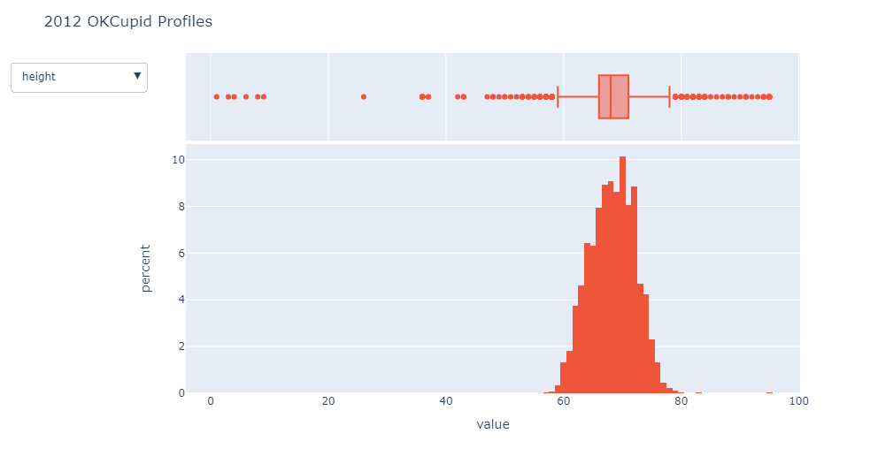

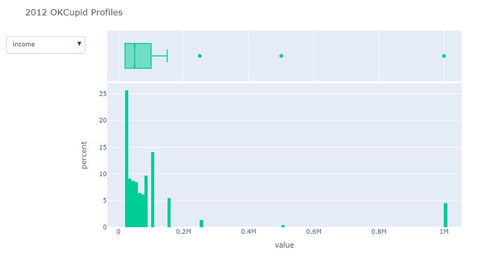

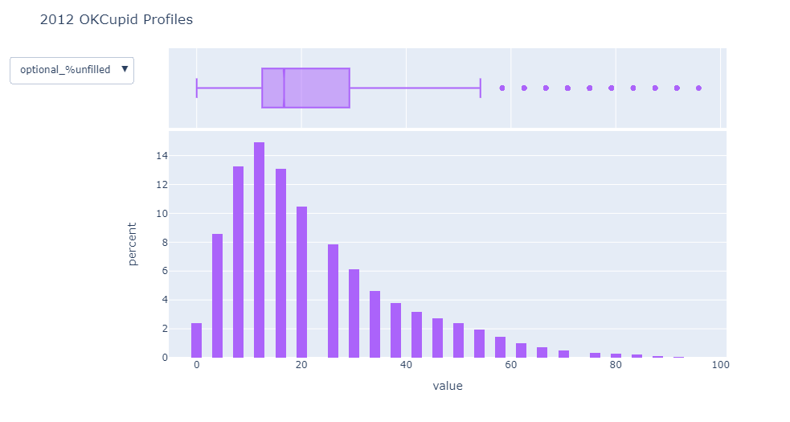

## Categorical Features

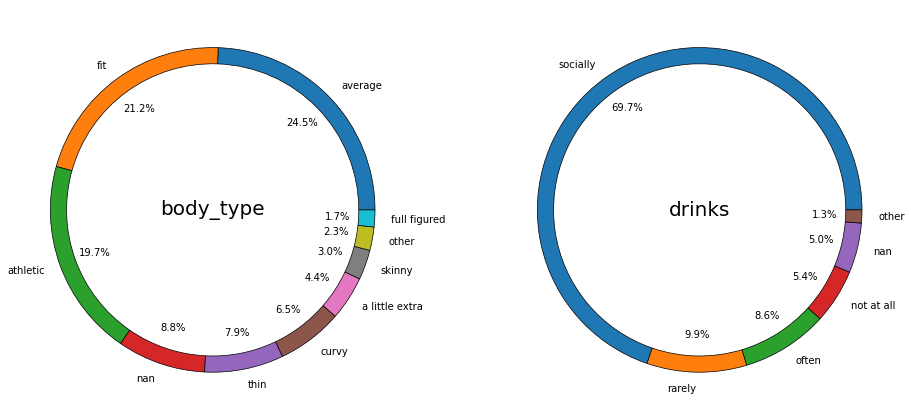

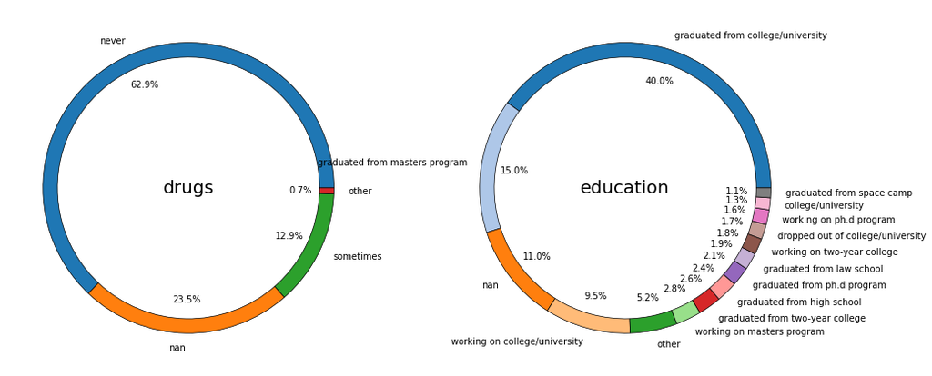

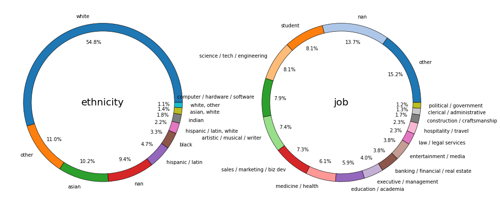

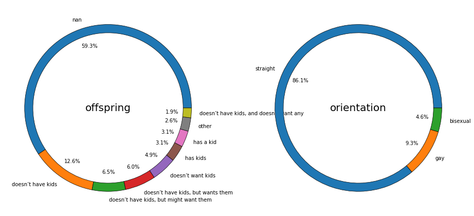

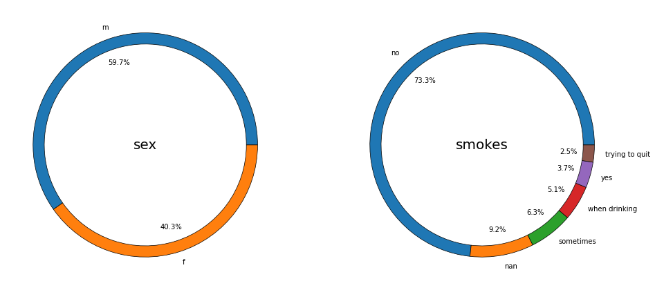

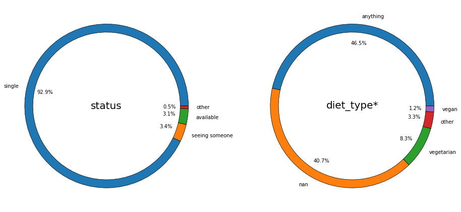

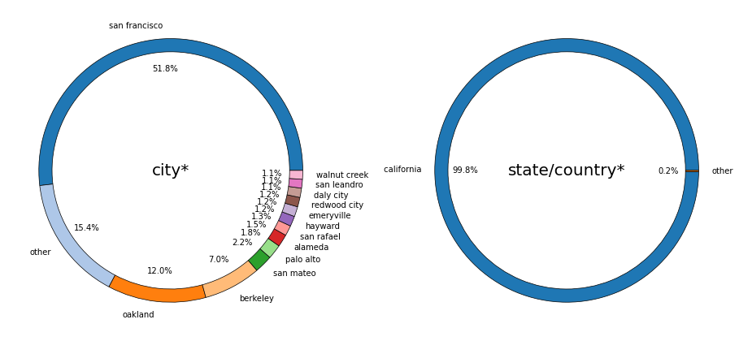

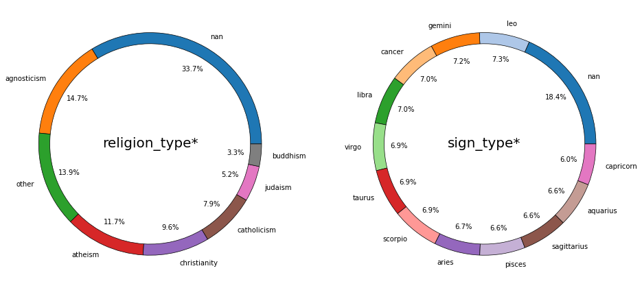

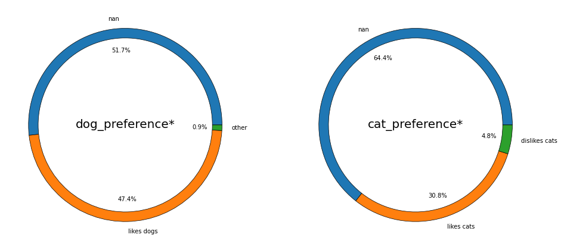

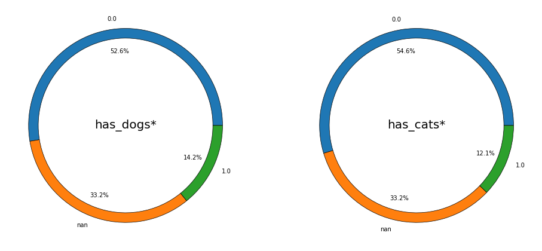

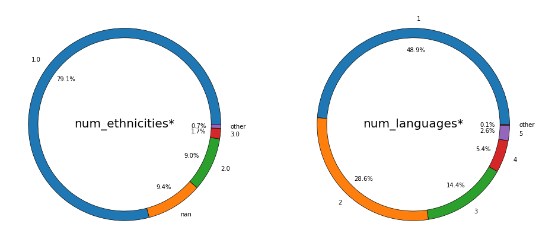

**The charts tell us that the typical profile on OKCupid back in 2012 was:**

- not fat or skinny
- has drinks socially
- doesn't do drugs
- finished college
- white ethnicity
- varied in terms of possible job background
- doesn't have kids
- straight
- male
- doesn't smoke
- single
- lives in San Francisco, California
- eats anything
- agnostic or atheist
- likes dogs and/or cats but doesn't have them
- not multiracial
- speaks only one language

It's possible that people misrepresent themselves on their profile, paint themselves more positively, and carefully omit negative information.

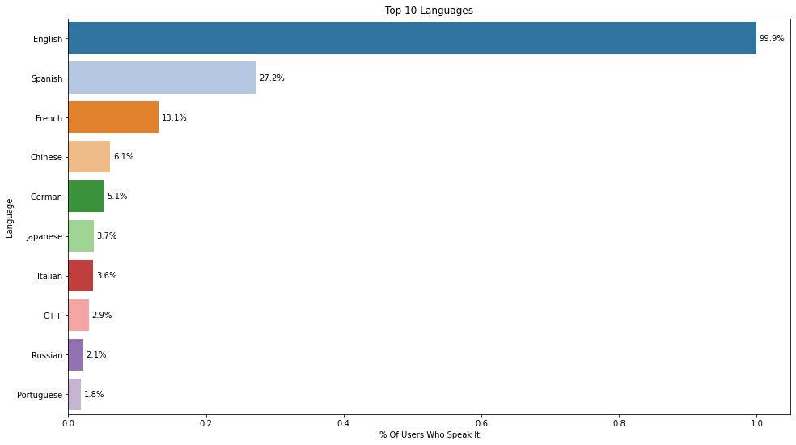

Everyone speaks English. Hilariously some people speak C++... *why not Python?*

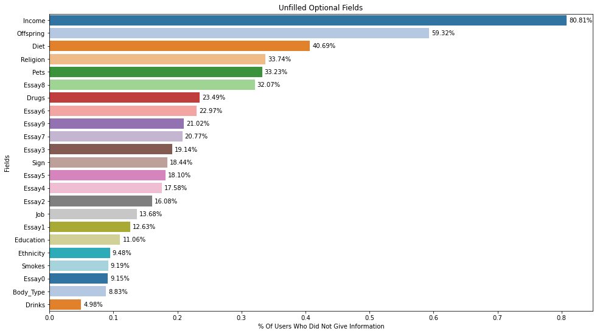

[output not shown]

## Essay Responses

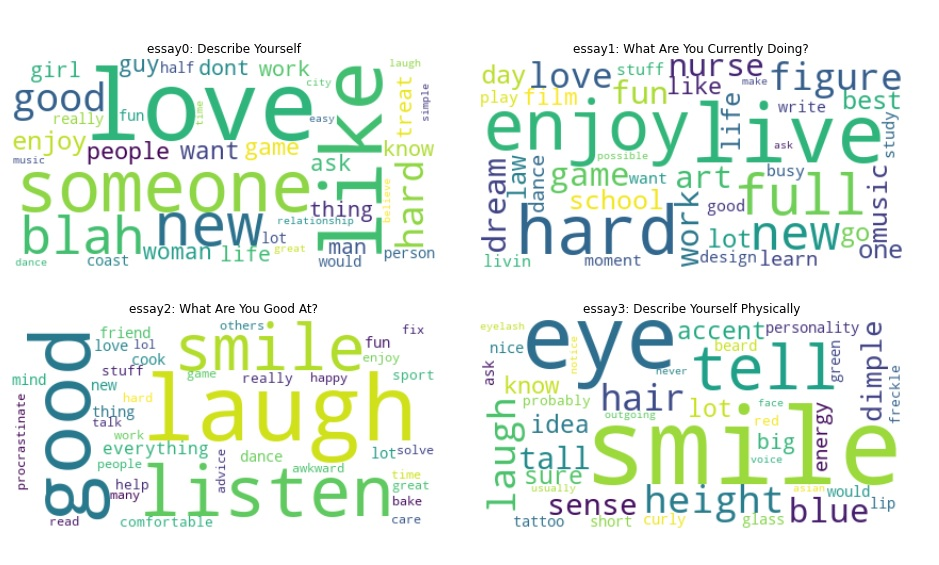

[figure not shown]

[output not shown]

# Date Recommendation using K-Means Clustering

*"Can we recommend who you should date?"*

Clustering, is a technique which groups similar data points together. Let's use this to group similar people together and recommend who you should date. People in the same cluster as you are the people who we will recommend.

## Feature Selection

Which, among the features, would you want your date to have in common with you?

After asking someone which features they would want to have in common with them, the chosen features are:

- Drugs
- Diet
- Pets
- Orientation
- Religion (attitude only)

## Choosing a value of k

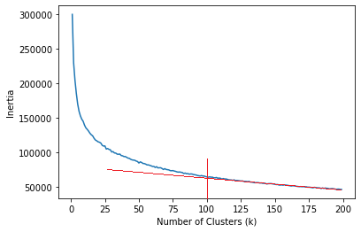

k = 100 is where the linearity begins. Let's create the model we will use for clustering with k = 100.

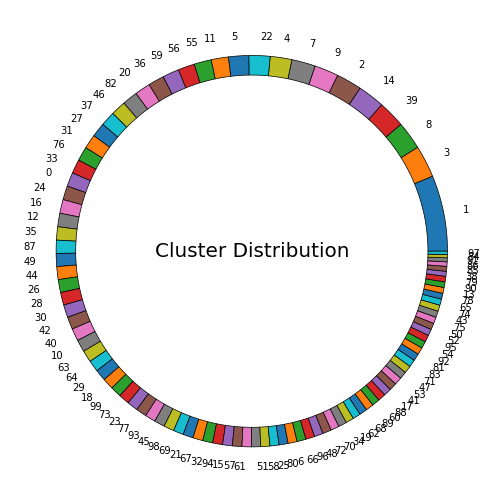

## Date Match Recommendations (only interactive if opened with Jupyter Notebooks and required packages are installed)

Let's discover who you can date! Select from the dropdown lists to enter your information. Click the 'Run Interact' button to predict your cluster number and display the profile of a potential date. Your cluster contains users that are similar to you - someone you might want to date! Click Run to see another random profile from your cluster.

- Note that as an experiment, null values have been included as their own category. The model groups people who similarly leave a lot of fields blank. The values of 'nan' or 'None' or 'No Prefix' means that you are not sharing information for that particular field. Go ahead and try out 'nan' and see how that affects your matches.

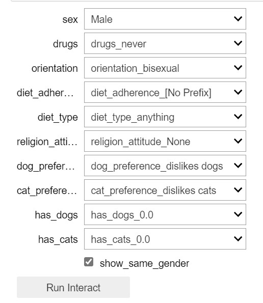

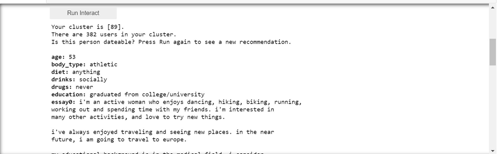

## Date Recommendation using K-Means Clustering Recap

In this section, we accomplished the following:

- Selected features for our model, on the basis of wanting a potential date to be similar for those particular features
- Used the 'elbow method' for selecting a value of k for our k-means clustering model
- Created an interactive interface for presenting profiles of suggested users to date based on input user data

# Predictive Models with Supervised Machine Learning

*"If a user's gender was kept hidden, can the other pieces of information be used to correctly predict the gender? If yes, what information was most important for making the prediction?"*

## Block Diagram of Model Tuning and Evaluation

[figure not shown]

### Parameter Tuning

#### Logistic Regression

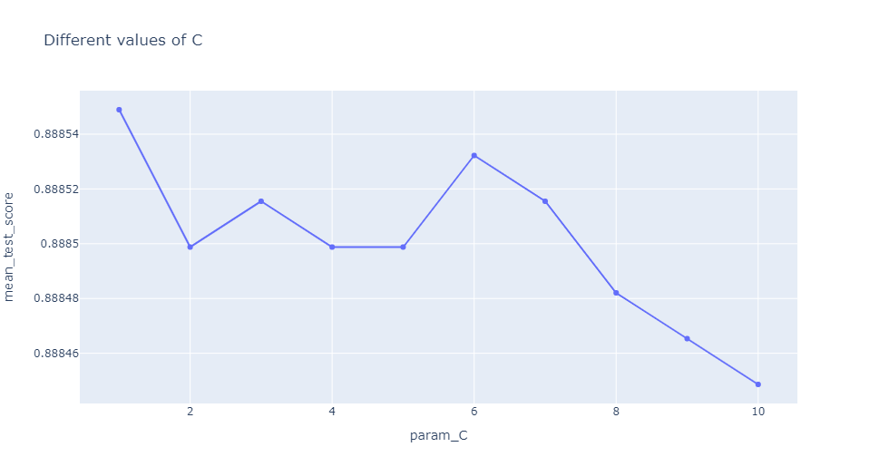

#### Decision Tree

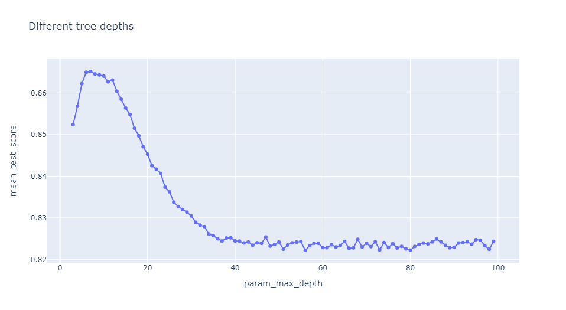

#### Random Forest

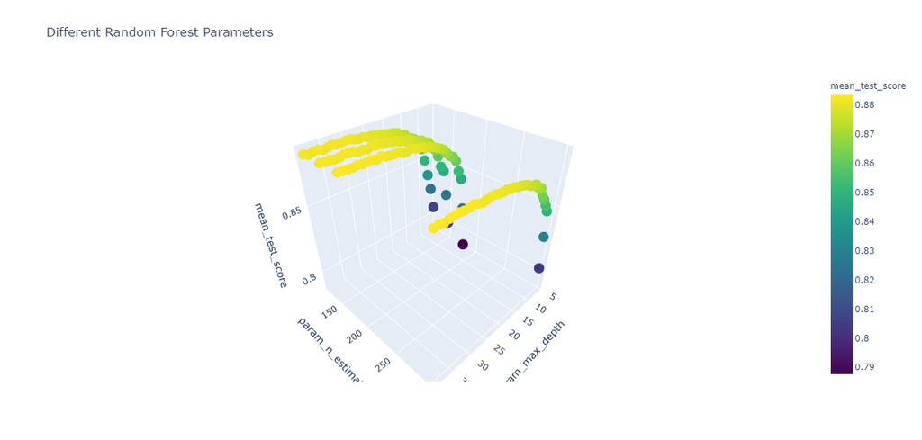

### Parameter Tuning Results

| Model | Parameter | Best Value |
| --- | --- | --- |
| Logistic Regression | C (Regularization Strength) | 1 |
| Decision Tree | Max Depth | 7 |
| Random Forest | Max Depth | 39 |
| Random Forest | N Estimators | 300 |

### Model Evaluation and Comparison

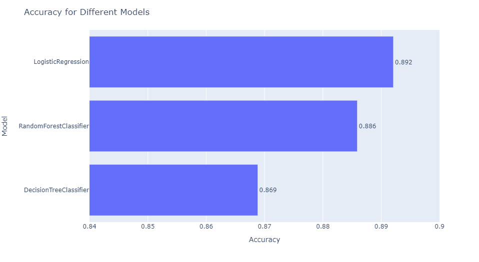

|  | actual_Female | actual_Male | Model |
| --- | --- | --- | --- |
| **pred_Female** | 85.586149 | 8.369368 | LogisticRegression |
| **pred_Male** | 14.413851 | 91.630632 | LogisticRegression |
| **pred_Female** | 80.767626 | 9.024969 | DecisionTreeClassifier |
| **pred_Male** | 19.232374 | 90.975031 | DecisionTreeClassifier |
| **pred_Female** | 83.166458 | 7.783512 | RandomForestClassifier |
| **pred_Male** | 16.833542 | 92.216488 | RandomForestClassifier |

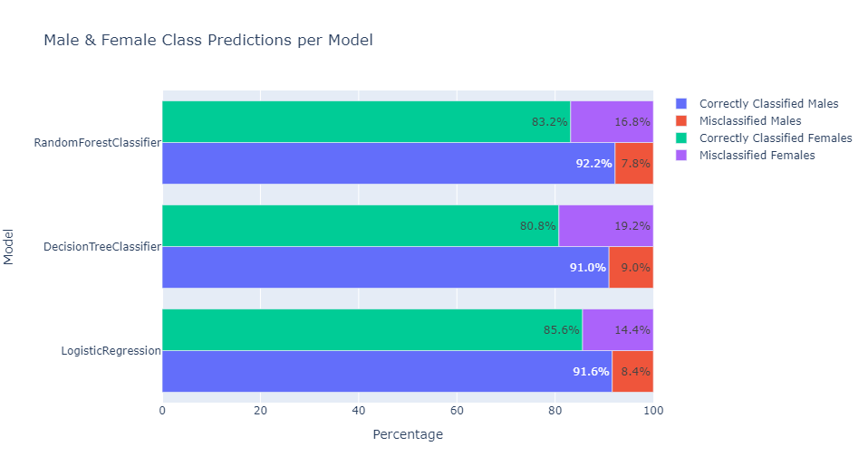

This is not without consequence in the real world. I recommend the Netflix documentary ["Coded Bias"](https://www.netflix.com/title/81328723). In the documentary, during a senate hearing, [Alexandra Ocasio-Cortez questions Joy Buolamwini](https://www.youtube.com/watch?v=mxektG_wU4w). Here is a selected excerpt:

AOC: "What demographic is it [AI models] mostly effective on?"  
JB: "White Men"  
AOC: "And who are the primary engineers and designers of these algorithms?"  
JB: "Definitely white men"

Despite the oral exchange above, it's possible to make a biased AI model without being a "white man". You could be an ML engineer who failed to properly evaluate the performance of your model at identifying all class labels. This issue has already entered the mainstream social and political spheres.

## Examination of Predictor Weights and Importances

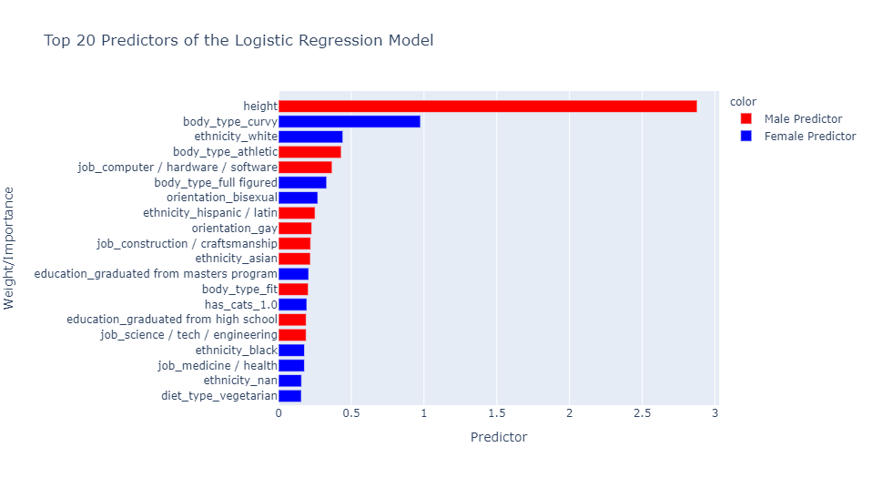

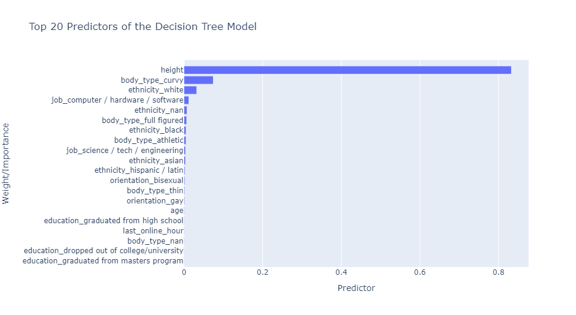

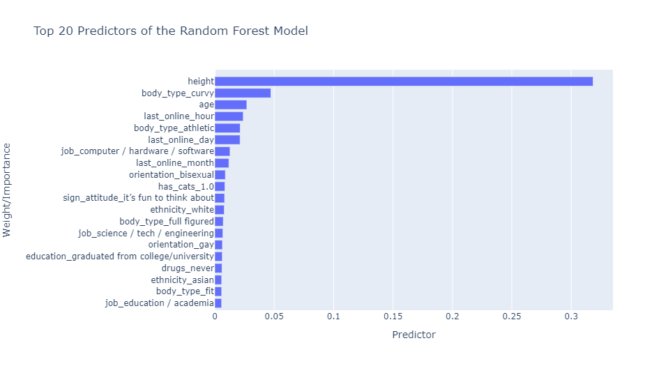

For all models, *height* and *body_type_curvy* are our top predictors. Probably because men are taller than women on average, and because men are not likely to describe themselves as curvy whereas women are. It is interesting to see that after the top two predictors, there is a different order of feature importances for the random forest compared to the other models.

With Logistic Regression we can conveniently see which features were more useful for predicting class (male or female) because we have negative and positive weight coefficients, unlike with the Random Forest and Decision Tree. We can see that the model has more confidence in its male predictors than in its female predictors.

## Next Steps

Although not presented here, most likely because the age distribution is skewed towards the young, the model is more effective at classifying young people than old people. The way to alleviate this is to apply a power transform to the age distribution, which makes it more like a normal distribution, before training (you will also have to apply the same transform to the test set before predicting). We will then have to evaluate the model's performance with young vs old subsets of our data.

Model evaluation can still be taken steps further. In scikit learn there is an [example](https://scikit-learn.org/stable/auto_examples/model_selection/plot_grid_search_stats.html) of applying frequentist and bayesian statistical approaches to more definitively make model comparisons.

Now that you know how to evaluate a model, the challenge is to learn how to improve model performance. Not just in general, but to be fair at identifying all classes. You will rarely ever have a dataset that is perfectly balanced.

# You've reached the end of this article. Thanks for reading it!